# part 2

```python
import pandas as pd
```

```python
df=pd.read_csv('covid_data.csv',encoding='latin-1')
df_2021=df[70130:122843].reset_index()
df_2020=df[0:70130]
```

```python
import numpy as np
```

```python
df_2020
```

|  | date | iso3c | country | income | region | continent | dcases | ddeaths | population | weekdays | month |
| --- | --- | --- | --- | --- | --- | --- | --- | --- | --- | --- | --- |
| 0 | 2020-02-24 | AFG | Afghanistan | Low income | South Asia | Asia | 5 | 0 | 38041754 | Mon | Feb |
| 1 | 2020-02-25 | AFG | Afghanistan | Low income | South Asia | Asia | 0 | 0 | 38041754 | Tue | Feb |
| 2 | 2020-02-26 | AFG | Afghanistan | Low income | South Asia | Asia | 0 | 0 | 38041754 | Wed | Feb |
| 3 | 2020-02-27 | AFG | Afghanistan | Low income | South Asia | Asia | 0 | 0 | 38041754 | Thu | Feb |
| 4 | 2020-02-28 | AFG | Afghanistan | Low income | South Asia | Asia | 0 | 0 | 38041754 | Fri | Feb |
| ... | ... | ... | ... | ... | ... | ... | ... | ... | ... | ... | ... |
| 70125 | 2020-12-27 | MCO | Monaco | High income | Europe & Central Asia | Europe | 0 | 0 | 38964 | Sun | Dec |
| 70126 | 2020-12-28 | MCO | Monaco | High income | Europe & Central Asia | Europe | 4 | 0 | 38964 | Mon | Dec |
| 70127 | 2020-12-29 | MCO | Monaco | High income | Europe & Central Asia | Europe | 26 | 0 | 38964 | Tue | Dec |
| 70128 | 2020-12-30 | MCO | Monaco | High income | Europe & Central Asia | Europe | 26 | 0 | 38964 | Wed | Dec |
| 70129 | 2020-12-31 | MCO | Monaco | High income | Europe & Central Asia | Europe | 22 | 0 | 38964 | Thu | Dec |

70130 rows × 11 columns

```python
df_2021
```

|  | index | date | iso3c | country | income | region | continent | dcases | ddeaths | population | weekdays | month |
| --- | --- | --- | --- | --- | --- | --- | --- | --- | --- | --- | --- | --- |
| 0 | 70130 | 2021-01-01 | MCO | Monaco | High income | Europe & Central Asia | Europe | 10 | 0 | 38964 | Fri | Jan |
| 1 | 70131 | 2021-01-02 | MCO | Monaco | High income | Europe & Central Asia | Europe | 16 | 0 | 38964 | Sat | Jan |
| 2 | 70132 | 2021-01-03 | MCO | Monaco | High income | Europe & Central Asia | Europe | 6 | 0 | 38964 | Sun | Jan |
| 3 | 70133 | 2021-01-04 | MCO | Monaco | High income | Europe & Central Asia | Europe | 10 | 0 | 38964 | Mon | Jan |
| 4 | 70134 | 2021-01-05 | MCO | Monaco | High income | Europe & Central Asia | Europe | 30 | 0 | 38964 | Tue | Jan |
| ... | ... | ... | ... | ... | ... | ... | ... | ... | ... | ... | ... | ... |
| 52708 | 122838 | 2021-12-27 | ZWE | Zimbabwe | Lower middle income | Sub-Saharan Africa | Africa | 1098 | 17 | 14645468 | Mon | Dec |
| 52709 | 122839 | 2021-12-28 | ZWE | Zimbabwe | Lower middle income | Sub-Saharan Africa | Africa | 2099 | 32 | 14645468 | Tue | Dec |
| 52710 | 122840 | 2021-12-29 | ZWE | Zimbabwe | Lower middle income | Sub-Saharan Africa | Africa | 0 | 0 | 14645468 | Wed | Dec |
| 52711 | 122841 | 2021-12-30 | ZWE | Zimbabwe | Lower middle income | Sub-Saharan Africa | Africa | 4180 | 57 | 14645468 | Thu | Dec |
| 52712 | 122842 | 2021-12-31 | ZWE | Zimbabwe | Lower middle income | Sub-Saharan Africa | Africa | 1530 | 7 | 14645468 | Fri | Dec |

52713 rows × 12 columns

```python
from pandas.api.types import CategoricalDtype
cats=['Jan', 'Feb', 'Mar','Apr','May','Jun','Jul','Aug','Sep','Oct','Nov','Dec']
cat_type = CategoricalDtype(categories=cats, ordered=True)
df_2021['month'] = df_2021['month'].astype(cat_type)
```

### Ratio of cases over deaths

```python
cases=df['dcases'].sum()
cases
```

```
289138394
```

```python
deaths=df['ddeaths'].sum()
deaths
```

```
5441088
```

```python
deaths/cases
```

```
0.01881828256955733
```

This means that, on average, for every 53 cases of covid-19, there is 1 death.

#### Distribution of all cases by time ; grouped by days (710 different days seen in the dataset)

Firstly, I had to calculate the mean of the number of cases for each day as there are many countries that reported total cases each day.

```python
Cases=df.groupby("date").agg({"dcases": [np.mean, np.size]})
Cases
```

| date | dcases mean | dcases size |
| --- | --- | --- |
| 2020-01-22 | 111.200000 | 5 |
| 2020-01-23 | 12.500000 | 8 |
| 2020-01-24 | 31.666667 | 9 |
| 2020-01-25 | 44.818182 | 11 |
| 2020-01-26 | 56.833333 | 12 |
| ... | ... | ... |
| 2021-12-27 | 6851.294118 | 187 |
| 2021-12-28 | 7117.636364 | 187 |
| 2021-12-29 | 9220.144385 | 187 |
| 2021-12-30 | 10376.641711 | 187 |
| 2021-12-31 | 9170.727273 | 187 |

710 rows × 2 columns

In order to easily interpret the graph, I generated ordered number from 0-710, that are the total number of days included in this dataset.

```python
pp=list(range(1, 711, 1))
```

```python
import matplotlib.pyplot as plt
```

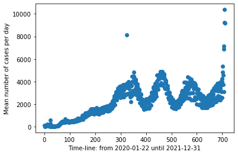

```python
plt.scatter(pp,Cases['dcases']['mean'])
plt.xlabel('Time-line: from 2020-01-22 until 2021-12-31')
plt.ylabel("Mean number of cases per day")
plt.show()
```

This graph implicates several interpretations. Firstly, during the first 300 days (2020)cases were increasing on average in an increasing rate. Then, during 2021, number of cases were fluctuating. This could be due to what is called waves; where the virus becomes vigurous in a certain period of time then less vigurous. As you can see, there were around 3 waves in 2021.

### Distribution of all deaths over time; grouped by days

```python
Deaths=df.groupby("date").agg({"ddeaths": [np.mean, np.size]})
Deaths
```

| date | ddeaths mean | ddeaths size |
| --- | --- | --- |
| 2020-01-22 | 3.400000 | 5 |
| 2020-01-23 | 0.125000 | 8 |
| 2020-01-24 | 0.888889 | 9 |
| 2020-01-25 | 1.454545 | 11 |
| 2020-01-26 | 1.166667 | 12 |
| ... | ... | ... |
| 2021-12-27 | 35.967914 | 187 |
| 2021-12-28 | 39.989305 | 187 |
| 2021-12-29 | 42.978610 | 187 |
| 2021-12-30 | 40.491979 | 187 |
| 2021-12-31 | 35.256684 | 187 |

710 rows × 2 columns

Note: The coloum 'mean' indicates the mean of different countries that reported cases. 'Size' is the number of countries that reported cases this day.

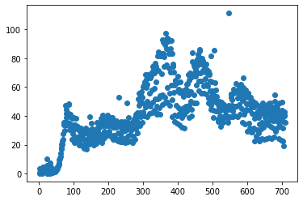

```python
plt.scatter(pp,Deaths['ddeaths']['mean'])
```

I expected that this graph would be similar to the graph describing the distribution of cases, but it I was wrong. In fact, here the trend is quite different. Number of deaths rapidly increased in the first 100 days of 2020, then became stable with around 40 deaths per day. At the end of 2020, deaths increased sevearly, reaching 100 deaths per day due to covid-19. Although fluctuations still clearly appears in 2021, the trend is decreasing.

To conclude, 2020 had an overall increase in both cases and deaths. And 2021 had an overall decrease in deaths, but a stable number of high cases and a slight increase in cases. However, graphs are totally different.

```python
import scipy
from scipy import stats
```

```python
df['totcases'] = df.groupby(['iso3c'])['dcases'].cumsum()
```

```python
df.loc[df['iso3c']=='EGY'].head(6)
```

[output not shown]

```python
df['totdeaths'].loc[df['iso3c']=='EGY']
```

[output not shown]

```python
df_egy=df.loc[df['iso3c']=='EGY']
```

```python
df['totdeaths'] = df.groupby(['iso3c'])['ddeaths'].cumsum()
```

```python
df['cfr']=df['totdeaths']/df['totcases']
```

```python
df_egy['date'] = pd.to_datetime(df['date'],format='%Y-%m-%d')
```

```python
df
```

|  | date | iso3c | country | income | region | continent | dcases | ddeaths | population | weekdays | month | totcases | totdeaths | cfr |
| --- | --- | --- | --- | --- | --- | --- | --- | --- | --- | --- | --- | --- | --- | --- |
| 0 | 2020-02-24 | AFG | Afghanistan | Low income | South Asia | Asia | 5 | 0 | 38041754 | Mon | Feb | 5 | 0 | 0.000000 |
| 1 | 2020-02-25 | AFG | Afghanistan | Low income | South Asia | Asia | 0 | 0 | 38041754 | Tue | Feb | 5 | 0 | 0.000000 |
| 2 | 2020-02-26 | AFG | Afghanistan | Low income | South Asia | Asia | 0 | 0 | 38041754 | Wed | Feb | 5 | 0 | 0.000000 |
| 3 | 2020-02-27 | AFG | Afghanistan | Low income | South Asia | Asia | 0 | 0 | 38041754 | Thu | Feb | 5 | 0 | 0.000000 |
| 4 | 2020-02-28 | AFG | Afghanistan | Low income | South Asia | Asia | 0 | 0 | 38041754 | Fri | Feb | 5 | 0 | 0.000000 |
| ... | ... | ... | ... | ... | ... | ... | ... | ... | ... | ... | ... | ... | ... | ... |
| 122838 | 2021-12-27 | ZWE | Zimbabwe | Lower middle income | Sub-Saharan Africa | Africa | 1098 | 17 | 14645468 | Mon | Dec | 205455 | 4908 | 0.023888 |
| 122839 | 2021-12-28 | ZWE | Zimbabwe | Lower middle income | Sub-Saharan Africa | Africa | 2099 | 32 | 14645468 | Tue | Dec | 207554 | 4940 | 0.023801 |
| 122840 | 2021-12-29 | ZWE | Zimbabwe | Lower middle income | Sub-Saharan Africa | Africa | 0 | 0 | 14645468 | Wed | Dec | 207554 | 4940 | 0.023801 |
| 122841 | 2021-12-30 | ZWE | Zimbabwe | Lower middle income | Sub-Saharan Africa | Africa | 4180 | 57 | 14645468 | Thu | Dec | 211734 | 4997 | 0.023600 |
| 122842 | 2021-12-31 | ZWE | Zimbabwe | Lower middle income | Sub-Saharan Africa | Africa | 1530 | 7 | 14645468 | Fri | Dec | 213264 | 5004 | 0.023464 |

122843 rows × 14 columns

[figure not shown]

```python
plt.plot( 'date', 'cfr', data=df_egy,  color='black', markersize=4,     linewidth=1)
plt.xlabel("")
plt.ylabel("CFR")
plt.show()
```

```python
df.loc[df['iso3c']=='ARG'].head(6)
```

|  | date | iso3c | country | income | region | continent | dcases | ddeaths | population | weekdays | month | totcases | totdeaths | cfr |
| --- | --- | --- | --- | --- | --- | --- | --- | --- | --- | --- | --- | --- | --- | --- |
| 3365 | 2020-03-03 | ARG | Argentina | Upper middle income | Latin America & Caribbean | South America(continent) | 1 | 0 | 44938712 | Tue | Mar | 1 | 0 | 0.000000 |
| 3366 | 2020-03-04 | ARG | Argentina | Upper middle income | Latin America & Caribbean | South America(continent) | 0 | 0 | 44938712 | Wed | Mar | 1 | 0 | 0.000000 |
| 3367 | 2020-03-05 | ARG | Argentina | Upper middle income | Latin America & Caribbean | South America(continent) | 0 | 0 | 44938712 | Thu | Mar | 1 | 0 | 0.000000 |
| 3368 | 2020-03-06 | ARG | Argentina | Upper middle income | Latin America & Caribbean | South America(continent) | 1 | 0 | 44938712 | Fri | Mar | 2 | 0 | 0.000000 |
| 3369 | 2020-03-07 | ARG | Argentina | Upper middle income | Latin America & Caribbean | South America(continent) | 6 | 0 | 44938712 | Sat | Mar | 8 | 0 | 0.000000 |
| 3370 | 2020-03-08 | ARG | Argentina | Upper middle income | Latin America & Caribbean | South America(continent) | 4 | 1 | 44938712 | Sun | Mar | 12 | 1 | 0.083333 |

```python
df['totdeaths'].loc[df['iso3c']=='ARG']
```

```
3365         0
3366         0
3367         0
3368         0
3369         0
         ...
4029    117066
4030    117085
4031    117111
4032    117146
4033    117169
Name: totdeaths, Length: 669, dtype: int64
```

```python
df_arg=df.loc[df['iso3c']=='ARG']
```

```python
df_arg['date'] = pd.to_datetime(df_arg['date'],format='%Y-%m-%d')
```

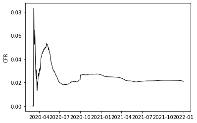

```python
plt.plot( 'date', 'cfr', data=df_arg,  color='black', markersize=4,     linewidth=1)
plt.xlabel("")
plt.ylabel("CFR")
plt.show()
```

this graph illustrates alse the major increase in the rate of dying if someone caught covid. However here, the graph levels out at around 2%. Which means less people are likely to die due to covid. This could be because Argentina is more advanced in technology and public health.

### Comparasion between 2020 and 2021 in several Factors

##### In terms of income:

```python
income_2020=df_2020.groupby("income").agg({"dcases": [np.mean]})
income_2020
```

| income | dcases mean |
| --- | --- |
| High income | 2611.055449 |
| Low income | 103.631519 |
| Lower middle income | 3143.069867 |
| Upper middle income | 2345.335069 |

```python
from pandas.api.types import CategoricalDtype
income=['Low income', 'Lower middle income', 'Upper middle income','High income']
income_type = CategoricalDtype(categories=income, ordered=True)
df_2021['income'] = df_2021['income'].astype(income_type)
```

```python
from pandas.api.types import CategoricalDtype
income=['Low income', 'Lower middle income', 'Upper middle income','High income']
income_type = CategoricalDtype(categories=income, ordered=True)
df_2021['income'] = df_2021['income'].astype(income_type)
```

```python
income_2020=df_2020.groupby("income").agg({"dcases": [np.mean]})
income_2020
```

| income | dcases mean |
| --- | --- |
| High income | 2611.055449 |
| Low income | 103.631519 |
| Lower middle income | 3143.069867 |
| Upper middle income | 2345.335069 |

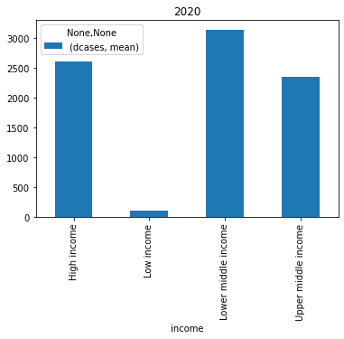

```python
income_2020.plot(kind='bar',title='2020')
plt. subplot()
```

In 2020 all groups of income were high with an average of 2600 cases per day except the low income group. This could be due to the fact that all income groups were reporting cases to the government and testing but the low income group. This could be because they do not want to pay for covid testing as they might be poor.Therefore, I think that the low income group had actually higher cases per day than an average of 103.

```python
income_2021=df_2021.groupby("income").agg({"dcases": [np.mean]})
income_2021
```

| income | dcases mean |
| --- | --- |
| Low income | 145.892537 |
| Lower middle income | 896.624482 |
| Upper middle income | 3044.696181 |
| High income | 5228.749643 |

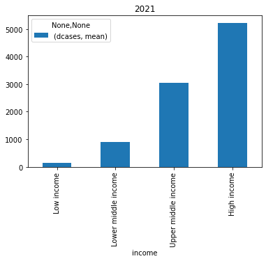

```python
income_2021.plot(kind='bar',title='2021')
```

My interpritation to this graph is that as the income increases the cases increases not because the high income people actually get infected more often, but because they test more as they care more about their health and are more willing to pay to make sure they are in good health. For example, if someone was coughing and was feeling sick, the probability that he would test if he was in the high income group would be higher that if a low income earner would test. Clearly because he is more eilling to pay and not because he is more likely to actually get infected.